# Heart_Attack_Risk_Predictor with Eval ML

## Heart Attack Risk Predictor

### Heart Attack Risk Predictor with Automated Machine Learning Techniques

The main purpose of this project is to predict whether a person is at risk of a heart attack or not, using automated Automated Machine Learning Techniques.

### What Causes a Heart Attack?

A heart attack occurs when one or more of your coronary arteries become blocked. Over time, a buildup of fatty deposits, including cholesterol, forms substances called plaques, which can narrow the arteries. This condition, called coronary artery disease, causes most heart attacks.

### Understanding the problem statement:

We are given a data set in which various attributes are provided, crucial for heart disease detection. We will build a model using Automated Machine Learning Techniques using this data.

AutoML is the process of automating the tasks of applying machine learning to real-world problems. We will be using EvalML Library. EvalML is an open-source AutoML library written in python that automates a more significant part of the machine learning process. We can quickly evaluate which machine learning pipeline works better for the given data set.

### Propose of this project?

In this project, we will first use different ML Algorithms. Then we will then understand how we can use Auto ML techniques, EvalML for this project to simplify our work.

### We will do the following things:

- Data Analysis
- Feature Engineering
- Satandardization
- Model Building
- Predictions

### Let us import the necessary liabraries and read our DataSet

```python
import pandas as pd
import numpy as np
import seaborn as sns
import matplotlib.pyplot as plt
%matplotlib inline
```

Let us import our Data Set

```python
df= pd.read_csv("heart.csv")
```

```python
df= df.drop(['oldpeak','slp','thall'],axis=1)
```

```python
df.head()
```

|  | age | sex | cp | trtbps | chol | fbs | restecg | thalachh | exng | caa | output |
| --- | --- | --- | --- | --- | --- | --- | --- | --- | --- | --- | --- |
| 0 | 63 | 1 | 3 | 145 | 233 | 1 | 0 | 150 | 0 | 0 | 1 |
| 1 | 37 | 1 | 2 | 130 | 250 | 0 | 1 | 187 | 0 | 0 | 1 |
| 2 | 41 | 0 | 1 | 130 | 204 | 0 | 0 | 172 | 0 | 0 | 1 |
| 3 | 56 | 1 | 1 | 120 | 236 | 0 | 1 | 178 | 0 | 0 | 1 |
| 4 | 57 | 0 | 0 | 120 | 354 | 0 | 1 | 163 | 1 | 0 | 1 |

### Understanding our DataSet:

In order to understand the purpose of this project we need to understand the data set and what each column is in our heart dataset.

#### Age : Age of the patient

#### Sex : Sex of the patient

#### Exang: exercise induced angina (1 = yes; 0 = no)

#### Ca: number of major vessels (0-3)

#### Cp : Chest Pain type chest pain type

- Value 0: typical angina
- Value 1: atypical angina
- Value 2: non-anginal pain
- Value 3: asymptomatic

#### Trtbps : resting blood pressure (in mm Hg)

#### Chol : cholestoral in mg/dl fetched via BMI sensor

#### Fbs : (fasting blood sugar > 120 mg/dl) (1 = true; 0 = false)

#### Rest_ecg : resting electrocardiographic results

- Value 0: normal
- Value 1: having ST-T wave abnormality (T wave inversions and/or ST elevation or depression of > 0.05 mV)
- Value 2: showing probable or definite left ventricular hypertrophy by Estes' criteria

#### Thalach : maximum heart rate achieved

#### Target :

- 0= less chance of heart attack
- 1= more chance of heart attack

What is a binary and if 0 there's less of a chance of getting a heart attack. a bar Target value is 1 there is a higher chance of getting a heart attack.

```python
df.shape
```

```
(303, 11)
```

As we can see will have 303 rows and 11 columns in our data set.

```python
df.isnull().sum()
```

```
age         0
sex         0
cp          0
trtbps      0
chol        0
fbs         0
restecg     0
thalachh    0
exng        0
caa         0
output      0
dtype: int64
```

As we can see there are no null values in our Data Set. This is extremely important to determined because Null values can lead to miscalculations During our data analysis process. It is extremely important to make sure there is no NULL values in our current Data Set. If our Data set had Null Values we will have to use different techniques to deal with them.

```python
df.corr()
```

|  | age | sex | cp | trtbps | chol | fbs | restecg | thalachh | exng | caa | output |
| --- | --- | --- | --- | --- | --- | --- | --- | --- | --- | --- | --- |
| age | 1.000000 | -0.098447 | -0.068653 | 0.279351 | 0.213678 | 0.121308 | -0.116211 | -0.398522 | 0.096801 | 0.276326 | -0.225439 |
| sex | -0.098447 | 1.000000 | -0.049353 | -0.056769 | -0.197912 | 0.045032 | -0.058196 | -0.044020 | 0.141664 | 0.118261 | -0.280937 |
| cp | -0.068653 | -0.049353 | 1.000000 | 0.047608 | -0.076904 | 0.094444 | 0.044421 | 0.295762 | -0.394280 | -0.181053 | 0.433798 |
| trtbps | 0.279351 | -0.056769 | 0.047608 | 1.000000 | 0.123174 | 0.177531 | -0.114103 | -0.046698 | 0.067616 | 0.101389 | -0.144931 |
| chol | 0.213678 | -0.197912 | -0.076904 | 0.123174 | 1.000000 | 0.013294 | -0.151040 | -0.009940 | 0.067023 | 0.070511 | -0.085239 |
| fbs | 0.121308 | 0.045032 | 0.094444 | 0.177531 | 0.013294 | 1.000000 | -0.084189 | -0.008567 | 0.025665 | 0.137979 | -0.028046 |
| restecg | -0.116211 | -0.058196 | 0.044421 | -0.114103 | -0.151040 | -0.084189 | 1.000000 | 0.044123 | -0.070733 | -0.072042 | 0.137230 |
| thalachh | -0.398522 | -0.044020 | 0.295762 | -0.046698 | -0.009940 | -0.008567 | 0.044123 | 1.000000 | -0.378812 | -0.213177 | 0.421741 |
| exng | 0.096801 | 0.141664 | -0.394280 | 0.067616 | 0.067023 | 0.025665 | -0.070733 | -0.378812 | 1.000000 | 0.115739 | -0.436757 |
| caa | 0.276326 | 0.118261 | -0.181053 | 0.101389 | 0.070511 | 0.137979 | -0.072042 | -0.213177 | 0.115739 | 1.000000 | -0.391724 |
| output | -0.225439 | -0.280937 | 0.433798 | -0.144931 | -0.085239 | -0.028046 | 0.137230 | 0.421741 | -0.436757 | -0.391724 | 1.000000 |

we are going to process our data set through the correlation function and as we could see above chard that is the results of the correlation. Correlation refers to a process for establishing the relationships between two variables. The value of 1 means that the two variables are completely correlated. This is only possible if we establish relationships between the same variables as we can see in our chart above. Suppose either -1 or 1 one means that they are highly correlated between the two variables of comparison. We're going to convert this to a more graphical form to better understand the relationship between the variables in terms of correlation.

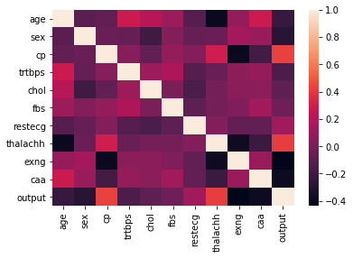

```python
sns.heatmap(df.corr())
```

#### As we can see from the diagram our variables are not highly correlated to each other.

As you can see our data from above gets converted into a graphical form. The darker the square is the less correlation the two variables that comparisons have to each other. The lighter the square is, the closer to the value 1 and the two variables a comparison is, have a higher correlation between the two variables.

#### We will do Uni and Bi variate analysis on our Features.

Univariate and Bivariate analysis in out data. Univariate analysis looks at one variable. This type of data consists of only one variable. The analysis of univariate data is thus the simplest form of analysis since the information deals with only one quantity that changes. Bivariate analysis looks at two variables and their relationship. This type of data involves two different variables. The analysis of this type of data deals with causes and relationships and the analysis is done to find out the relationship among the two variables. This is important to get a better understanding how the correlation is distributed through our data. Now we're going to find how the age of the patient is distributed throughout our Data Set. This is important so we could have a better understanding of our data in order to make the best interpretation when we start analyzing the data set further down the process.

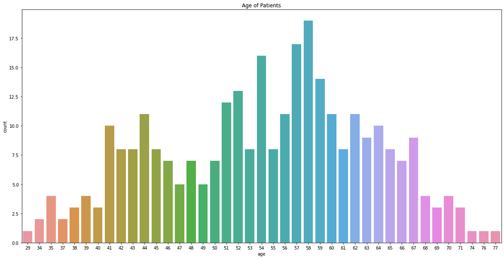

```python
plt.figure(figsize=(20, 10))
plt.title("Age of Patients")
plt.xlabel("Age")
sns.countplot(x='age',data=df)
```

#### As we can see the Patients are of Age Group 51-67 years in majority.

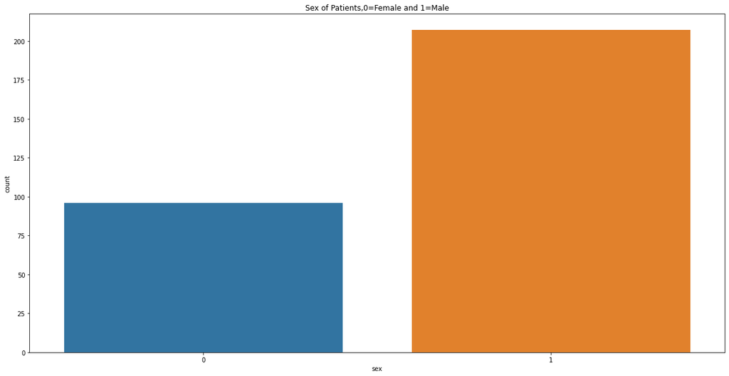

```python
plt.figure(figsize=(20, 10))
plt.title("Sex of Patients,0=Female and 1=Male")

sns.countplot(x='sex',data=df)
```

You can see from the graph above after graphing our data that we can see the Sex of Patients. 0=Female and 1=Male. We can clearly see that there is more than 100 more males in our data sets than females. This would be extremely important during our findings later on after analysis of our data.

```python
cp_data= df['cp'].value_counts().reset_index()
cp_data['index'][3]= 'asymptomatic'
cp_data['index'][2]= 'non-anginal'
cp_data['index'][1]= 'Atyppical Anigma'
cp_data['index'][0]= 'Typical Anigma'
cp_data
```

|  | index | cp |
| --- | --- | --- |
| 0 | Typical Anigma | 143 |
| 1 | Atyppical Anigma | 87 |
| 2 | non-anginal | 50 |
| 3 | asymptomatic | 23 |

As we can see from the data for chest pain of patients. Angina is chest pain or discomfort caused when your heart muscle doesn't get enough oxygen-rich blood. It may feel like pressure or squeezing in your chest. The discomfort also can occur in your shoulders, arms, neck, jaw, abdomen or back. Angina pain may even feel like indigestion. In addition, some people don’t feel any pain but have other symptoms like shortness of breath or fatigue. But angina is not a disease. It's a symptom of an underlying heart problem. We see from the diagram below from our Data set.

- Typical Anigma is 143 patients.
- Atyppical Anigma is 87 patients.
- Non-anginal is 50 patients.
- Asymptomatic is 23 patients.

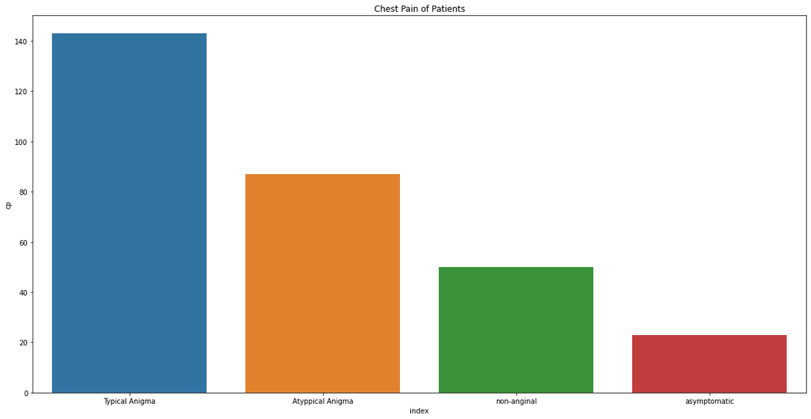

```python
plt.figure(figsize=(20, 10))
plt.title("Chest Pain of Patients")

sns.barplot(x=cp_data['index'],y= cp_data['cp'])
```

#### We have seen how the the Chest Pain Category is distributed

```python
ecg_data= df['restecg'].value_counts().reset_index()
ecg_data['index'][0]= 'normal'
ecg_data['index'][1]= 'having ST-T wave abnormality'
ecg_data['index'][2]= 'showing probable or definite left ventricular hypertrophy by Estes'

ecg_data
```

|  | index | restecg |
| --- | --- | --- |
| 0 | normal | 152 |
| 1 | having ST-T wave abnormality | 147 |
| 2 | showing probable or definite left ventricular ... | 4 |

### Now we going to do the same for our ECG values.

An ECG is used to see how the heart is functioning. It mainly records how often the heart beats (heart rate) and how regularly it beats (heart rhythm). It can give us important information, for instance about possible narrowing of the coronary arteries, a heart attack or an irregular heartbeat like atrial fibrillation.

- Normal Rest ECG is 152 patients.
- ST-T wave abnormailty is 147 patients.
- Showing probable of definite lest venticular hypertrophy is 4 patients.

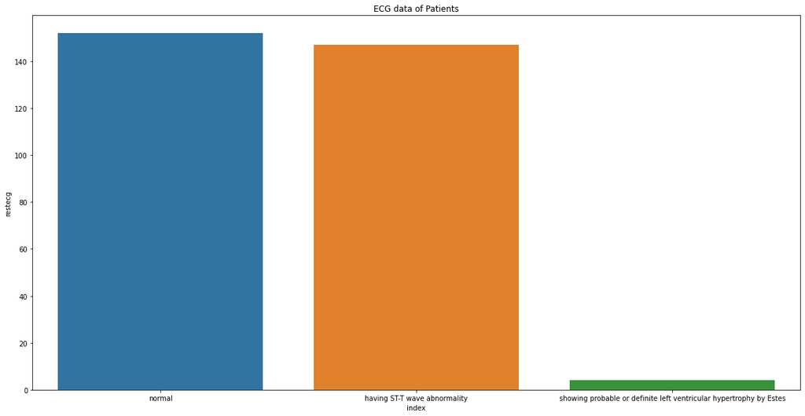

```python
plt.figure(figsize=(20, 10))
plt.title("ECG data of Patients")

sns.barplot(x=ecg_data['index'],y= ecg_data['restecg'])
```

#### This is our ECG Data

We could see our distribution of ECG data and we could see that from the normal to show me probable signs of issues.

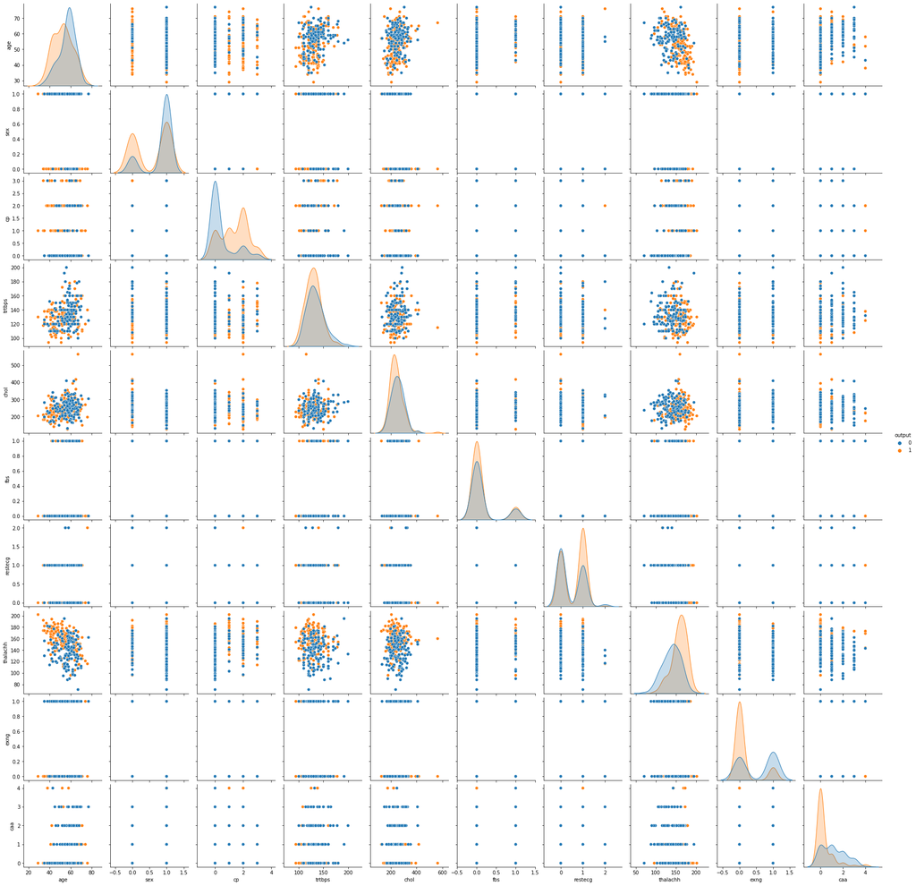

```python
sns.pairplot(df,hue='output',data=df)
```

Now, after this, we can have multivariate analysis. Multivariate analysis is based on the principles of multivariate statistics, which involves observation and analysis of more than one statistical outcome variable at a time. This will tell us how all the features are correlated to each other and also distributed throughout our Data Set. This is done in the form of different bar chart and distribution charts. This is the same as above but it is in the form of a different charge which corresponds to the multivariable analysis. As we can see hue is this 1 or 0. 0 is blue and 1 is orange in our diagram above. We can see that our x and y axis gives us different features. As you can see the different types of graphs above. It gives us an idea how data is distributed throughout our Data Set.

### Now let us see for our Continuous Variables

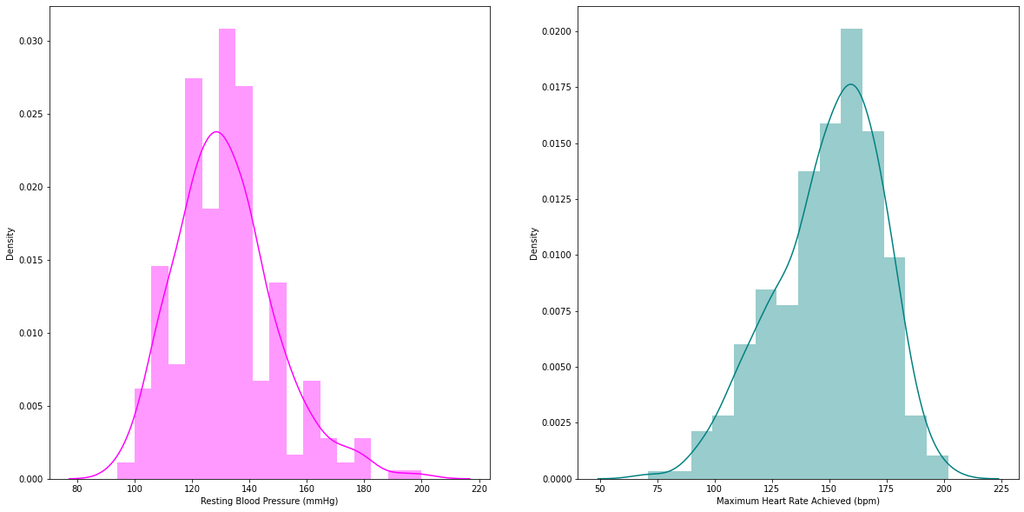

```python
plt.figure(figsize=(20,10))
plt.subplot(1,2,1)
sns.distplot(df['trtbps'], kde=True, color = 'magenta')
plt.xlabel("Resting Blood Pressure (mmHg)")
plt.subplot(1,2,2)
sns.distplot(df['thalachh'], kde=True, color = 'teal')
plt.xlabel("Maximum Heart Rate Achieved (bpm)")
```

The first graph is resting blodd pressure and the other graph is maximum heart rate achieved. This is a very good sign because in order to feed our data through our models our data has to be normally distributed to get our best results.

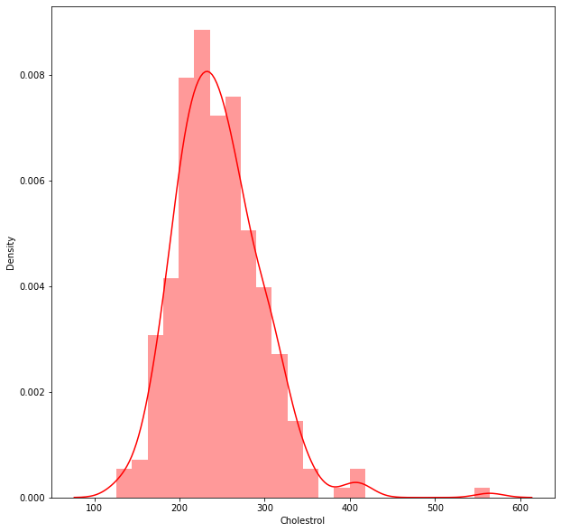

```python
plt.figure(figsize=(10,10))
sns.distplot(df['chol'], kde=True, color = 'red')
plt.xlabel("Cholestrol")
```

#### We have done the Analysis of the data

Now we have to do the same thing for our cholesterol. As you can see are data is normally distributed throughout our data. this is a good sign this means that we can use our data to feed our models. However there are some outliers in our data, Not too many so we don't have to worry about it affecting our data that much.

```python
df.head()
```

|  | age | sex | cp | trtbps | chol | fbs | restecg | thalachh | exng | caa | output |
| --- | --- | --- | --- | --- | --- | --- | --- | --- | --- | --- | --- |
| 0 | 63 | 1 | 3 | 145 | 233 | 1 | 0 | 150 | 0 | 0 | 1 |
| 1 | 37 | 1 | 2 | 130 | 250 | 0 | 1 | 187 | 0 | 0 | 1 |
| 2 | 41 | 0 | 1 | 130 | 204 | 0 | 0 | 172 | 0 | 0 | 1 |
| 3 | 56 | 1 | 1 | 120 | 236 | 0 | 1 | 178 | 0 | 0 | 1 |
| 4 | 57 | 0 | 0 | 120 | 354 | 0 | 1 | 163 | 1 | 0 | 1 |

### Let us do Standardisation

Now we will apply a technique called standardscaler. StandardScaler is an important technique that is mainly performed as a preprocessing step before many machine learning models, in order to standardize the range of functionality of the input dataset. We use a standardized to scale the Data Set values to get the best results when using our models. Then to fit our model we have you standard scaler for our data set.

```python
from sklearn.preprocessing import StandardScaler
```

```python
scale=StandardScaler()
```

```python
scale.fit(df)
```

```
StandardScaler()
```

```python
df= scale.transform(df)
```

```python
df=pd.DataFrame(df,columns=['age', 'sex', 'cp', 'trtbps', 'chol', 'fbs', 'restecg', 'thalachh',
       'exng', 'caa', 'output'])
```

```python
df.head()
```

|  | age | sex | cp | trtbps | chol | fbs | restecg | thalachh | exng | caa | output |
| --- | --- | --- | --- | --- | --- | --- | --- | --- | --- | --- | --- |
| 0 | 0.952197 | 0.681005 | 1.973123 | 0.763956 | -0.256334 | 2.394438 | -1.005832 | 0.015443 | -0.696631 | -0.714429 | 0.914529 |
| 1 | -1.915313 | 0.681005 | 1.002577 | -0.092738 | 0.072199 | -0.417635 | 0.898962 | 1.633471 | -0.696631 | -0.714429 | 0.914529 |
| 2 | -1.474158 | -1.468418 | 0.032031 | -0.092738 | -0.816773 | -0.417635 | -1.005832 | 0.977514 | -0.696631 | -0.714429 | 0.914529 |
| 3 | 0.180175 | 0.681005 | 0.032031 | -0.663867 | -0.198357 | -0.417635 | 0.898962 | 1.239897 | -0.696631 | -0.714429 | 0.914529 |
| 4 | 0.290464 | -1.468418 | -0.938515 | -0.663867 | 2.082050 | -0.417635 | 0.898962 | 0.583939 | 1.435481 | -0.714429 | 0.914529 |

### We can insert this data into our ML Models

### We will use the following models for our predictions :

- Logistic Regression - is used to calculate the probability of a binary event occurring, and to deal with issues of classification
- Decision Tree - is a type of flowchart that shows a clear pathway to a decision. In terms of data analytics, it is a type of algorithm that includes conditional 'control' statements to classify data.
- Random Forest - is a powerful and versatile supervised machine learning algorithm that grows and combines multiple decision trees to create a "forest." It can be used for both classification and regression problems.
- K Nearest Neighbor - is one of the most basic yet essential classification algorithms in Machine Learning. It belongs to the supervised learning domain and finds intense application in pattern recognition, data mining and intrusion detection.
- SVM - is a type of deep learning algorithm that performs supervised learning for classification or regression of data groups. In AI and machine learning, supervised learning systems provide both input and desired output data, which are labeled for classification.

#### Then we will use the ensembling techniques

#### Let us split our data

However, to accomplish all these models above we have to split our data to dependent and independent variables in order to analyze our data correctly through all the different type of models we are going to use.

```python
x= df.iloc[:,:-1]
x
```

|  | age | sex | cp | trtbps | chol | fbs | restecg | thalachh | exng | caa |
| --- | --- | --- | --- | --- | --- | --- | --- | --- | --- | --- |
| 0 | 0.952197 | 0.681005 | 1.973123 | 0.763956 | -0.256334 | 2.394438 | -1.005832 | 0.015443 | -0.696631 | -0.714429 |
| 1 | -1.915313 | 0.681005 | 1.002577 | -0.092738 | 0.072199 | -0.417635 | 0.898962 | 1.633471 | -0.696631 | -0.714429 |
| 2 | -1.474158 | -1.468418 | 0.032031 | -0.092738 | -0.816773 | -0.417635 | -1.005832 | 0.977514 | -0.696631 | -0.714429 |
| 3 | 0.180175 | 0.681005 | 0.032031 | -0.663867 | -0.198357 | -0.417635 | 0.898962 | 1.239897 | -0.696631 | -0.714429 |
| 4 | 0.290464 | -1.468418 | -0.938515 | -0.663867 | 2.082050 | -0.417635 | 0.898962 | 0.583939 | 1.435481 | -0.714429 |
| ... | ... | ... | ... | ... | ... | ... | ... | ... | ... | ... |
| 298 | 0.290464 | -1.468418 | -0.938515 | 0.478391 | -0.101730 | -0.417635 | 0.898962 | -1.165281 | 1.435481 | -0.714429 |
| 299 | -1.033002 | 0.681005 | 1.973123 | -1.234996 | 0.342756 | -0.417635 | 0.898962 | -0.771706 | -0.696631 | -0.714429 |
| 300 | 1.503641 | 0.681005 | -0.938515 | 0.706843 | -1.029353 | 2.394438 | 0.898962 | -0.378132 | -0.696631 | 1.244593 |
| 301 | 0.290464 | 0.681005 | -0.938515 | -0.092738 | -2.227533 | -0.417635 | 0.898962 | -1.515125 | 1.435481 | 0.265082 |
| 302 | 0.290464 | -1.468418 | 0.032031 | -0.092738 | -0.198357 | -0.417635 | -1.005832 | 1.064975 | -0.696631 | 0.265082 |

303 rows × 10 columns

We can see from our chart above X is our independent variable

```python
y= df.iloc[:,-1:]
y
```

|  | output |
| --- | --- |
| 0 | 0.914529 |
| 1 | 0.914529 |
| 2 | 0.914529 |
| 3 | 0.914529 |
| 4 | 0.914529 |
| ... | ... |
| 298 | -1.093459 |
| 299 | -1.093459 |
| 300 | -1.093459 |
| 301 | -1.093459 |
| 302 | -1.093459 |

303 rows × 1 columns

We can see from our chart above Y is our dependent variable

```python
from sklearn.model_selection import train_test_split
x_train, x_test, y_train, y_test = train_test_split(x, y, test_size=0.3, random_state=101)
```

From Sklean.Model_selection will are going to import train_test_split, x_train, x_test, y_train, y_test variables. We are using the trian_test_split funciton. This function is going to take our data set and feed it to different variables. These variables are going to be used in our various different models.

### Logistic Regression

```python
from sklearn.linear_model import LogisticRegression # import from sklearn
```

```python
from sklearn.preprocessing import LabelEncoder # this is needed for preprocessing of out data
```

```python
# we are using labelencoder we have bring y_trian to zero for our data set
lbl= LabelEncoder()
```

```python
encoded_y= lbl.fit_transform(y_train)
```

```python
logreg= LogisticRegression()
```

```python
logreg = LogisticRegression()
logreg.fit(x_train, encoded_y)
```

```
LogisticRegression(C=1.0, class_weight=None, dual=False, fit_intercept=True,
                   intercept_scaling=1, l1_ratio=None, max_iter=100,
                   multi_class='auto', n_jobs=None, penalty='l2',
                   random_state=None, solver='lbfgs', tol=0.0001, verbose=0,
                   warm_start=False)
```

```python
Y_pred1
```

[output not shown]

```python
#Import the accuracy score
from sklearn.metrics import accuracy_score
#Import the confusion matriax
from sklearn.metrics import confusion_matrix
```

```python
encoded_ytest= lbl.fit_transform(y_test)
```

```python
Y_pred1 = logreg.predict(x_test)
lr_conf_matrix = confusion_matrix(encoded_ytest,Y_pred1 )
lr_acc_score = accuracy_score(encoded_ytest, Y_pred1)
```

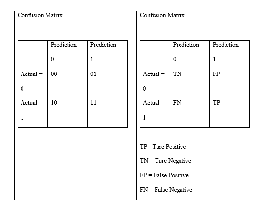

```python
lr_conf_matrix
```

```
array([[35,  9],
       [ 4, 43]])
```

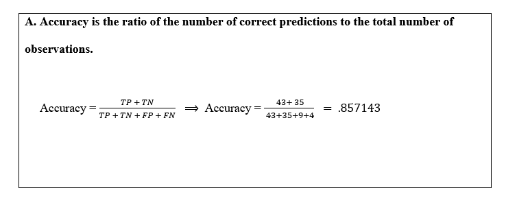

Once again, a logistic regression model's goal is to predict whether the binary response Y takes on a value of 0 or 1. We can see that our accuracy is .857143, which is close to 1. Accuracy is the ratio of the number of correct predictions to the total number of observations. When assessing the classification model's performance, our accuracy is near one, which is extremely well, which means that. Our model is doing a good job in distinguishing what is in a binary value, said what is a 0 and what is a 1. Then we should expect good results are moving forward with her model and Theory.

```python
print(lr_acc_score*100,"%")
```

```
85.71428571428571 %
```

### Decision Tree

```python
from sklearn.tree import DecisionTreeClassifier
```

```python
tree= DecisionTreeClassifier()
```

```python
tree.fit(x_train,encoded_y)
```

```
DecisionTreeClassifier(ccp_alpha=0.0, class_weight=None, criterion='gini',
                       max_depth=None, max_features=None, max_leaf_nodes=None,
                       min_impurity_decrease=0.0, min_impurity_split=None,
                       min_samples_leaf=1, min_samples_split=2,
                       min_weight_fraction_leaf=0.0, presort='deprecated',
                       random_state=None, splitter='best')
```

```python
ypred2=tree.predict(x_test)
```

```python
encoded_ytest= lbl.fit_transform(y_test)
```

```python
tree_conf_matrix = confusion_matrix(encoded_ytest,ypred2 )
tree_acc_score = accuracy_score(encoded_ytest, ypred2)
```

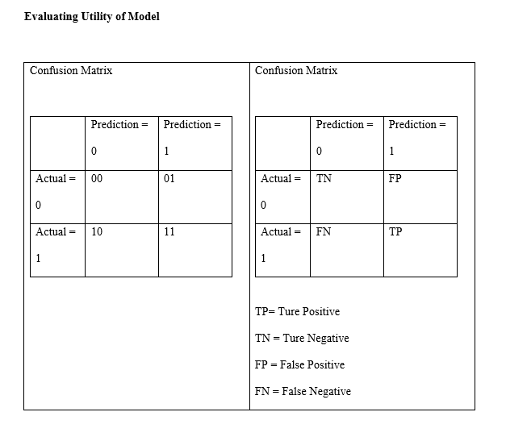

```python
tree_conf_matrix
```

```
array([[26, 18],
       [ 9, 38]])
```

[figure not shown]

```python
print(tree_acc_score*100,"%")
```

```
70.32967032967034 %
```

#### As we see our Decision Tree Model does not perform well as it gives a score of only 70%

The Heart Attack Risk Predictor model is 70% accurate. Though, I think more variables need to be analyzed and evaluated to find which variable will produce the highest probability of finding the model that best fits the situation. The whole objective is to develop a model that is custom to the scenario, however, this is not the best results.

### Random Forest

```python
from sklearn.ensemble import RandomForestClassifier
```

```python
rf= RandomForestClassifier()
```

```python
rf.fit(x_train,encoded_y)
```

```
RandomForestClassifier(bootstrap=True, ccp_alpha=0.0, class_weight=None,
                       criterion='gini', max_depth=None, max_features='auto',
                       max_leaf_nodes=None, max_samples=None,
                       min_impurity_decrease=0.0, min_impurity_split=None,
                       min_samples_leaf=1, min_samples_split=2,
                       min_weight_fraction_leaf=0.0, n_estimators=100,
                       n_jobs=None, oob_score=False, random_state=None,
                       verbose=0, warm_start=False)
```

```python
ypred3 = rf.predict(x_test)
```

```python
rf_conf_matrix = confusion_matrix(encoded_ytest,ypred3 )
rf_acc_score = accuracy_score(encoded_ytest, ypred3)
```

What is the use of training and testing sets when creating a random forest model? Random forest is a viral machine learning algorithm to make predictions on classification and regression problems. The critical part of the random forest is that the algorithm uses not just one but multiple learners to obtain better predictive performance. Then we use the multiple decision trees on the training data to make predictions. We were able to obtain a model that we then use to make predictions on the testing data set. However, how would the predictions occur well? In case we use classification data sets, we have to predict a binary variable. For example, yes or no, we can use the majority rule to create a random forest model with decision trees. We can then drive down the classification model to split the point into multiple samples to better predict the actual model. Using the training set and testing said is extremely important and creating a random forest model.

```python
rf_conf_matrix
```

```
array([[30, 14],
       [ 8, 39]])
```

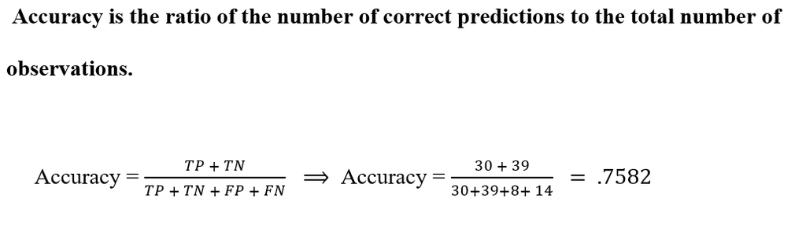

Once again, our model's goal is to predict whether the binary response Y takes on a value of 0 or 1. We can see that our accuracy is 75.82417. Accuracy is the ratio of the number of correct predictions to the total number of observations. When assessing the classification model's performance, our accuracy is near one, which is not doinf well, which means that. Our model is not doing a job in distinguishing what is in a binary value, said what is a 0 and what is a 1.

```python
print(rf_acc_score*100,"%")
```

```
75.82417582417582 %
```

#### Random Forest also gives us an accuracy of around 75%

### K Nearest Neighbour

#### We have to select what k we will use for the maximum accuracy

#### Let's write a function for it

```python
from sklearn.neighbors import KNeighborsClassifier
```

```python
error_rate= []
for i in range(1,40):
    knn= KNeighborsClassifier(n_neighbors=i)
    knn.fit(x_train,encoded_y)
    pred= knn.predict(x_test)
    error_rate.append(np.mean(pred != encoded_ytest))
```

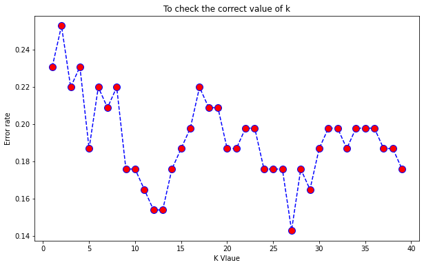

```python
plt.figure(figsize=(10,6))
plt.plot(range(1,40),error_rate,color='blue', linestyle='dashed', marker='o',
         markerfacecolor='red', markersize=10)
plt.xlabel('K Vlaue')
plt.ylabel('Error rate')
plt.title('To check the correct value of k')
plt.show()
```

```python
knn= KNeighborsClassifier(n_neighbors=12)
knn.fit(x_train,encoded_y)
ypred4= knn.predict(x_test)
```

```python
knn_conf_matrix = confusion_matrix(encoded_ytest,ypred4 )
knn_acc_score = accuracy_score(encoded_ytest, ypred4)
```

```python
knn_conf_matrix
```

```
array([[35,  9],
       [ 5, 42]])
```

```python
print(knn_acc_score*100,"%")
```

```
84.61538461538461 %
```

#### As we see KNN gives us an accuracy of around 85% which is good

### Support Vector Machine(SVM)

```python
from sklearn import svm
```

```python
svm= svm.SVC()
```

```python
svm.fit(x_train,encoded_y)
```

```
SVC(C=1.0, break_ties=False, cache_size=200, class_weight=None, coef0=0.0,
    decision_function_shape='ovr', degree=3, gamma='scale', kernel='rbf',
    max_iter=-1, probability=False, random_state=None, shrinking=True,
    tol=0.001, verbose=False)
```

```python
ypred5= svm.predict(x_test)
```

```python
svm_conf_matrix = confusion_matrix(encoded_ytest,ypred5)
svm_acc_score = accuracy_score(encoded_ytest, ypred5)
```

```python
svm_conf_matrix
```

```
array([[34, 10],
       [ 8, 39]])
```

```python
print(svm_acc_score*100,"%")
```

```
80.21978021978022 %
```

#### We get an accuracy of 80% in SVM

#### Let us see our model accuracy in Table form

Now we can going to add our accuracy for Logistic Regression, Decision Tree, Random Forest, K nearest neighbor and SVM to a DataFrame so we can compare the model accuracy.

```python
model_acc= pd.DataFrame({'Model' : ['Logistic Regression','Decision Tree','Random Forest','K Nearest Neighbor','SVM'],'Accuracy' : [lr_acc_score*100,tree_acc_score*100,rf_acc_score*100,knn_acc_score*100,svm_acc_score*100]})
```

```python
model_acc = model_acc.sort_values(by=['Accuracy'],ascending=False)
```

```python
model_acc
```

|  | Model | Accuracy |
| --- | --- | --- |
| 0 | Logistic Regression | 85.714286 |
| 3 | K Nearest Neighbor | 84.615385 |
| 4 | SVM | 80.219780 |
| 2 | Random Forest | 75.824176 |
| 1 | Decision Tree | 70.329670 |

Logistic Regression model had the highest accuracy at around 85 percent. These are some of the more primitive model that are used in machine learning.

#### Let us use one more Techniques known as Adaboost, this is a Boosting technique which uses multiple models for better accuracy.

AdaBoost as one of the best weighted combinations of classifiers – and one that is sensitive to noise, and conducive to certain machine learning results. Some confusion results from the reality that AdaBoost can be used with multiple instances of the same classifier with different parameters – where professionals might talk about AdaBoost "having only one classifier" and get confused about how weighting occurs.

AdaBoost also presents a particular philosophy in machine learning – as an ensemble learning tool, it proceeds from the fundamental idea that many weak learners can get better results than one stronger learning entity. With AdaBoost, machine learning experts are often crafting systems that will take in a number of inputs and combine them for an optimized result.

### Adaboost Classifier

#### Let us first use some random parameters for training the model without Hypertuning.

```python
from sklearn.ensemble import AdaBoostClassifier
```

```python
adab= AdaBoostClassifier(base_estimator=svm,n_estimators=100,algorithm='SAMME',learning_rate=0.01,random_state=0)
```

```python
adab.fit(x_train,encoded_y)
```

```
AdaBoostClassifier(algorithm='SAMME',
                   base_estimator=SVC(C=1.0, break_ties=False, cache_size=200,
                                      class_weight=None, coef0=0.0,
                                      decision_function_shape='ovr', degree=3,
                                      gamma='scale', kernel='rbf', max_iter=-1,
                                      probability=False, random_state=None,
                                      shrinking=True, tol=0.001,
                                      verbose=False),
                   learning_rate=0.01, n_estimators=100, random_state=0)
```

```python
ypred6=adab.predict(x_test)
```

```python
adab_conf_matrix = confusion_matrix(encoded_ytest,ypred6)
adab_acc_score = accuracy_score(encoded_ytest, ypred6)
```

```python
adab_conf_matrix
```

```
array([[ 0, 44],
       [ 0, 47]])
```

```python
print(adab_acc_score*100,"%")
```

```
51.64835164835166 %
```

```python
adab.score(x_train,encoded_y)
```

```
0.5566037735849056
```

```python
adab.score(x_test,encoded_ytest)
```

```
0.5164835164835165
```

#### As we see our model has performed very poorly with just 50% accuracy

As we can see we got worse results than our other models that were used. This can occur because parameters need to be more fine tuned to get better Accuracy.

#### We will use Grid Seach CV for HyperParameter Tuning

Hyperparameter Tuning with GridSearch Cross-Validation (CV) is another technique to find the best parameters for your model. To perform hyperparameter tuning with Grid Search using Scikit Learn (Sklearn).

### Grid Search CV

#### Let us try Grid Search CV for our top 3 performing Algorithms for HyperParameter tuning

```python
from sklearn.model_selection import GridSearchCV
```

```python
model_acc
```

|  | Model | Accuracy |
| --- | --- | --- |
| 0 | Logistic Regression | 85.714286 |
| 3 | K Nearest Neighbor | 84.615385 |
| 4 | SVM | 80.219780 |
| 2 | Random Forest | 75.824176 |
| 1 | Decision Tree | 70.329670 |

### Logistic Regression

```python
param_grid= {

    'solver': ['newton-cg', 'lbfgs', 'liblinear','sag', 'saga'],
    'penalty' : ['none', 'l1', 'l2', 'elasticnet'],
    'C' : [100, 10, 1.0, 0.1, 0.01]

}
```

We have different attributes that we're going to define for our logistic regression model.

```python
grid1= GridSearchCV(LogisticRegression(),param_grid)
```

```python
grid1.fit(x_train,encoded_y)
```

[output not shown]

[output cut: 285 more lines]

[output not shown]

```
GridSearchCV(cv=None, error_score=nan,
             estimator=LogisticRegression(C=1.0, class_weight=None, dual=False,
                                          fit_intercept=True,
                                          intercept_scaling=1, l1_ratio=None,
                                          max_iter=100, multi_class='auto',
                                          n_jobs=None, penalty='l2',
                                          random_state=None, solver='lbfgs',
                                          tol=0.0001, verbose=0,
                                          warm_start=False),
             iid='deprecated', n_jobs=None,
             param_grid={'C': [100, 10, 1.0, 0.1, 0.01],
                         'penalty': ['none', 'l1', 'l2', 'elasticnet'],
                         'solver': ['newton-cg', 'lbfgs', 'liblinear', 'sag',
                                    'saga']},
             pre_dispatch='2*n_jobs', refit=True, return_train_score=False,
             scoring=None, verbose=0)
```

```python
grid1.best_params_
```

```
{'C': 0.01, 'penalty': 'l2', 'solver': 'liblinear'}
```

'C': 0.01, 'penalty': 'l2', 'solver': 'liblinear' are our parameters we're going to apply to our regression model.